# 2019-BKM- Sectoral Distribution of Expenditures

# Group Mujde ‘R’

## 1.Introduction

We examined the data of BKM, “Sectoral Distribution of Expenditures in 6 Months in 2019”.

The web site is here: [BKM-Secilen aya ait sektorel gelisim](https://bkm.com.tr/secilen-aya-ait-sektorel-gelisim/?filter_year=2019&filter_month=6&List=Listele)

We have compiled the data in excel and upload the raw data in our repository. Used Tidyverse, GGplot2 and Scales from Library of R.

```r
library(tidyverse)
library(ggplot2)
library(scales)
```

## 2.Download Raw Data and Organize Data

We can automatically download the raw data from our repository and put it in a temporary file. Then we can read that excel document into R and remove the temp file.

```r
tmp<-tempfile(fileext=".xlsx")
download.file("https://github.com/pjournal/mef03g-mujde-r/blob/master/2019-BKM%20Rapor-Konsolide.xlsx?raw=true",destfile=tmp, mode="wb")
raw_data<-readxl::read_excel(tmp,col_names=FALSE,skip=1)
```

```r
file.remove(tmp)
```

```
## [1] TRUE
```

To organize the data, rename The Columns:

```r
colnames(raw_data)<-c("Months","Sector","Numb_CC","Numb_DC","Amount_CC","Amount_DC")
```

Let’s see the Data:

```r
head(raw_data)
```

```
## # A tibble: 6 x 6
##   Months Sector                         Numb_CC Numb_DC Amount_CC Amount_DC
##   <chr>  <chr>                            <dbl>   <dbl>     <dbl>     <dbl>
## 1 6-2019 ARABA KIRALAMA                  306426  7.71e4      257.     43.8
## 2 6-2019 ARAÇ KIRALAMA-SATIS/SERVIS/Y~  3335321  9.02e5     2589.    191.
## 3 6-2019 BENZIN VE YAKIT ISTASYONLARI  32572382  1.38e7     6516.   1195.
## 4 6-2019 BIREYSEL EMEKLILIK             2060390  1.26e3      687.      0.42
## 5 6-2019 ÇESITLI GIDA                  31076151  2.04e7     5148.    995.
## 6 6-2019 DOGRUDAN PAZARLAMA              738068  4.53e4      724.     21.3
```

- *Amounts are divided by 1 Million*

## 3.Analysis

### 3.1.The Distribution of Total Expenditures by Sectors in 6 Months

Let’s calculate the sectoral distribution of expenditures proportionally:

```r
Sectoral_Sum<-raw_data%>%select(Months,Sector,Amount_CC,Amount_DC)%>%mutate(Amount_Sum = Amount_CC+Amount_DC)%>%filter(Sector!="TOPLAM")

Sectoral_Sum<-Sectoral_Sum%>%group_by(Sector)%>%summarise(Amount_Sum=sum(Amount_Sum))%>%mutate(sec_prp=percent(Amount_Sum/sum(Amount_Sum)))%>%arrange(desc(Amount_Sum))
```

The sectors with the highest total expenditure in 6 months are as follows:

```r
Top_Ten_Sector<-head(Sectoral_Sum,10)
print(Top_Ten_Sector)
```

```
## # A tibble: 10 x 3
##    Sector                                Amount_Sum sec_prp
##    <chr>                                      <dbl> <chr>
##  1 MARKET VE ALISVERIS MERKEZLERI            83789. 18.4%
##  2 GIYIM VE AKSESUAR                         39850. 8.8%
##  3 BENZIN VE YAKIT ISTASYONLARI              39811. 8.7%
##  4 ÇESITLI GIDA                              33589. 7.4%
##  5 HIZMET SEKTÖRLERI                         28406. 6.2%
##  6 YEMEK                                     22506. 4.9%
##  7 ELEKTRIK-ELEKTRONIK ESYA, BILGISAYAR      21039. 4.6%
##  8 SAGLIK/SAGLIK ÜRÜNLERI/KOZMETIK           19206. 4.2%
##  9 YAPI MALZEMELERI, HIRDAVAT, NALBURIYE     17692. 3.9%
## 10 SIGORTA                                   16356. 3.6%
```

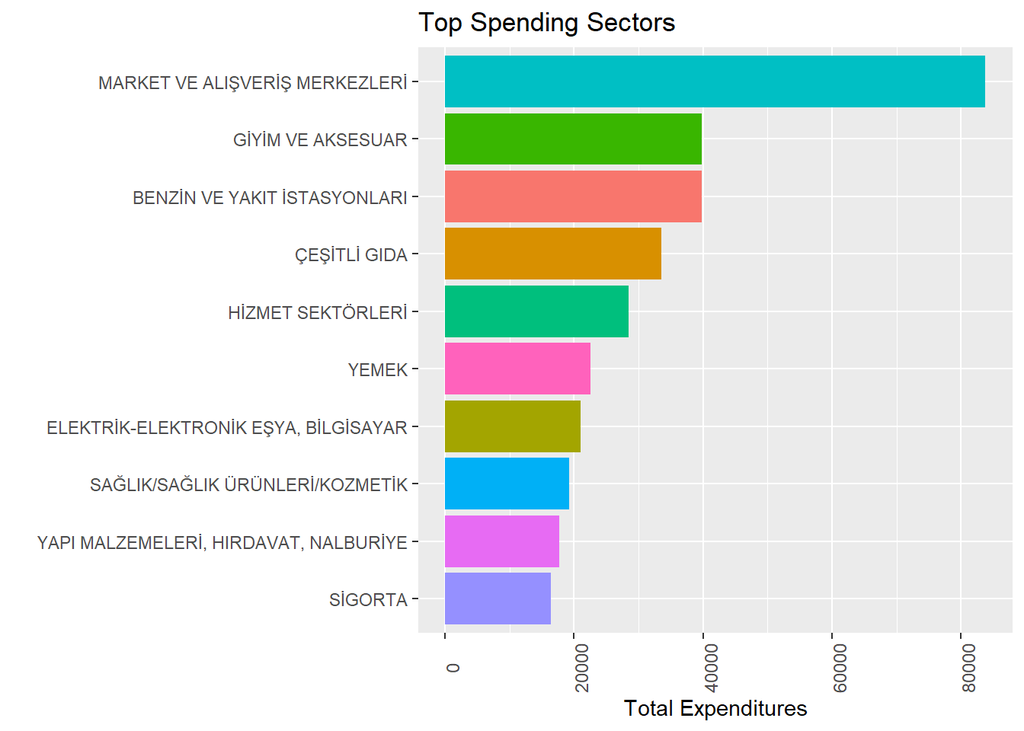

```r
Top_Ten_Sector%>%ggplot(
  aes(x=reorder(Sector,Amount_Sum),y=Amount_Sum,fill= Sector)) + geom_bar(stat="identity") +
  theme(legend.position = "none", axis.text.x = element_text(size=9,angle = 90)) + coord_flip() + labs(x="",y="Total Expenditures",title="Top Spending Sectors",fill="")
```

### 3.2.Distribution by Type of Cards

Let’s see the total distribution of expenditures made as credit card or debit card, by sectors.

```r
Card_Dist<-raw_data%>%filter(Sector!="TOPLAM")%>%group_by(Sector)%>%summarise(
  CC=sum(Numb_CC),
  DC=sum(Numb_DC))%>%mutate(Sum_Card=CC+DC)%>%arrange(desc(Sum_Card))%>%pivot_longer(cols=CC:DC,names_to="Card_Type",values_to="Count_Of_Cards")%>%print(n=6)
```

```
## # A tibble: 52 x 4
##   Sector                          Sum_Card Card_Type Count_Of_Cards
##   <chr>                              <dbl> <chr>              <dbl>
## 1 MARKET VE ALISVERIS MERKEZLERI 957742221 CC             615280253
## 2 MARKET VE ALISVERIS MERKEZLERI 957742221 DC             342461968
## 3 YEMEK                          486166406 CC             254907222
## 4 YEMEK                          486166406 DC             231259184
## 5 ÇESITLI GIDA                   286302262 CC             179587854
## 6 ÇESITLI GIDA                   286302262 DC             106714408
## # ... with 46 more rows
```

Sectors with the highest spending by total number of cards are as follows:

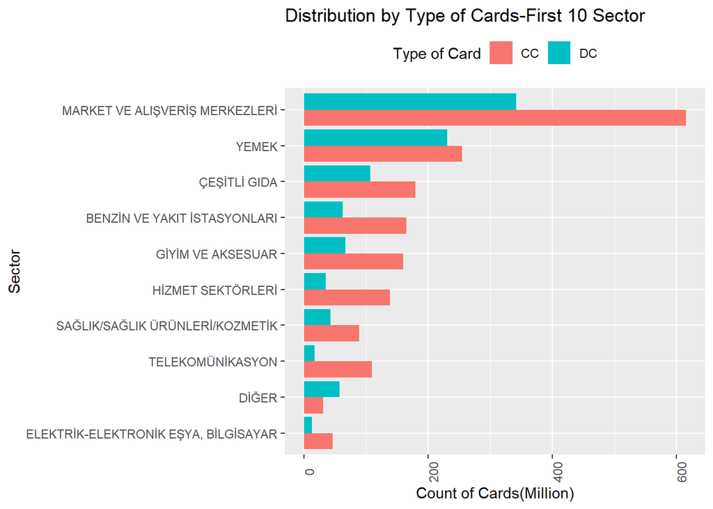

```r
Top_Ten_Card<-head(Card_Dist,20)

ggplot(Top_Ten_Card,aes(x=reorder(Sector,Sum_Card), y=Count_Of_Cards/1000000,fill=Card_Type))+geom_bar(stat="identity",position="dodge")+theme(axis.text.x = element_text(size=9,angle = 90),legend.position = "top") + coord_flip()+labs(x="Sector",y="Count of Cards(Million)",title="Distribution by Type of Cards-First 10 Sector",fill="Type of Card")
```

### 3.3.How is the Difference between Credit Card and Debit Card Spending

Let’s determine in which sectors credit card usage is not very different from debit card usage.

```r
Card_Comp<-raw_data%>%group_by(Sector)%>%summarise(sum_CC_amount=sum(Amount_CC),sum_DC_amount=sum(Amount_DC))%>%filter(Sector!="TOPLAM")

Card_Comp<-Card_Comp%>%mutate(Diff_Card_Amount=sum_CC_amount-sum_DC_amount)%>%arrange(Diff_Card_Amount)%>%print(10)
```

```
## # A tibble: 26 x 4
##    Sector                      sum_CC_amount sum_DC_amount Diff_Card_Amount
##    <chr>                               <dbl>         <dbl>            <dbl>
##  1 KUMARHANE/IÇKILI YERLER              533.        205.               328.
##  2 ARABA KIRALAMA                      1259.        136.              1124.
##  3 KULÜP / DERNEK /SOSYAL HIZ~         1548.        195.              1353.
##  4 KUYUMCULAR                          5938.       2546.              3393.
##  5 BIREYSEL EMEKLILIK                  4250.          2.91            4248.
##  6 MÜTEAHHIT ISLERI                    4713.        244.              4470.
##  7 DOGRUDAN PAZARLAMA                  4590.         82.8             4507.
##  8 SEYAHAT ACENTELERI/TASIMAC~         7801.       2621.              5180.
##  9 KONAKLAMA                           7440.       2083.              5357.
## 10 EGITIM / KIRTASIYE / OFIS ~         6901.       1427.              5473.
## # ... with 16 more rows
```

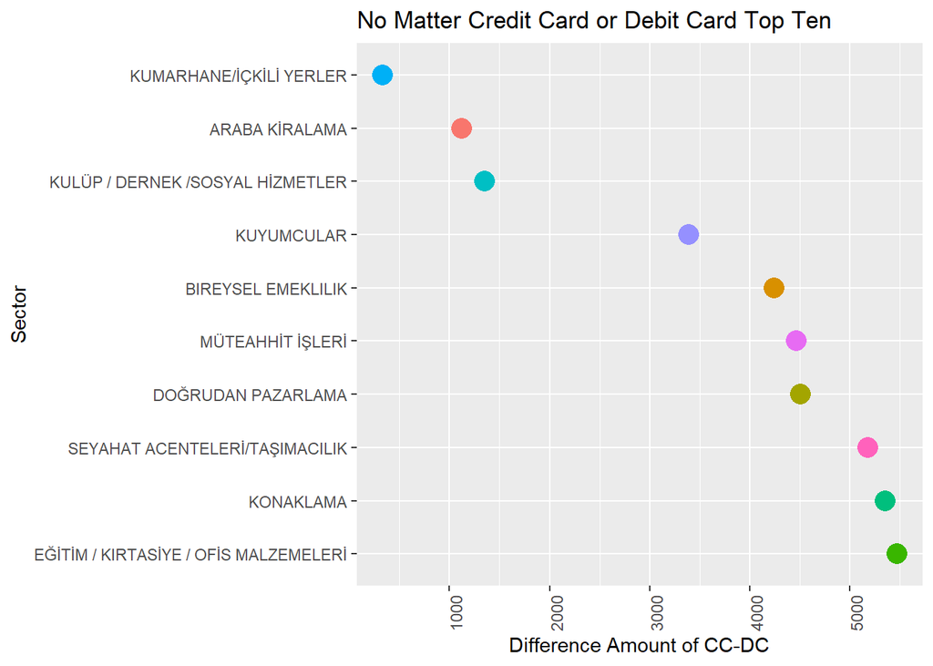

```r
Top_Card_Comp<-head(Card_Comp,10)

Top_Card_Comp%>%ggplot(aes(x=reorder(Sector,-Diff_Card_Amount),y=Diff_Card_Amount,color=Sector))+geom_point(size=5)+coord_flip()+theme(axis.text.x = element_text(size=9,angle=90),legend.position ="None") + labs(x="Sector",y="Difference Amount of CC-DC",title="No Matter Credit Card or Debit Card Top Ten",color="sector")
```

#### The End :)